# Proyecto I

[figure not shown]

## TP2- ITBA Relevamiento y análisis de Bases de datos

Profesoras:

Bouret, María Gabriela

Peralta Ramos, Angélica

Ian Dalton - 62345

Fecha de entrega: 17/4/23

## Ficha del dataset

**Nombre del dataset:** microdatos evyth

**Fuente:** [Ministerio de Turismo y Deportes](https://datos.gob.ar/dataset/turismo-encuesta-viajes-turismo-hogares-evyth)

**Rango de fechas:**

Desde: 1/1/2012

Hasta: 31/12/2022

**Cantidad de filas:** 434806

**Frecuencia de actualización:** Trimestral

**Problemas en la base:** - No tiene fechas especificas lo cual limita un poco el analisis para ver en que periodos va la gente

- La fecha de actualizacion de la pagina es del 6 de octubre de 2021 y tiene datos del cuarto trimestre de 2022.

**Potencial de esta base:** - Tiene un monton de preguntas que se hacen, desde cosas basicas como de donde vienen y a donde van hasta si contrataron un paquete de viaje y que cosas incluye

- Se podria analizar los medios de transporte o porque estan haciendo este viaje
- Tiene mucha informacion de que cosas hace en el viaje asi que se pueden hacer un monton de preguntas

**Breve descripción:** Es una base de datos que recopila de manera trimestral las respuestas de las encuestas que la gente responde al viajar

**Preguntas a hacer a la base:** - Que tanto se usa internet para organizar el viaje (reservas, etc.)

- Cuales son los destinos mas visitados, cual es el motivo y que medios de transporte usan
- Que influencio la decision de visitar el destino?
- Que tan seguido visitan el destino
- Que tipos de actividades se realizan en el destino
- Como la paso en el destino, cuales son los mejores y peores destinos filtrando por motivo (mejores lugares religiosos, turisticos, etc.)
- Mostrar la calidad promedio de en las provincias (se podria hacer un top mejores y peores):
  - Gastronomia
  - Alojamiento
  - Informacion turistica
  - Higiene
  - Seguridad
  - Transporte (filtrando por tipo de transporte)
- Tamaño de la familia del que viaja
- Edad promedio de la gente que responde la encuesta en relacion al destino que visita.
- Nivel educativo de lugar que se visita y de donde viene
- Nivel educativo y cobertura de salud
- Cobertura de salud y destino/origen
- Si la gente que no va por motivo religioso realiza una actividad religiosa
- Preparacion promedio que se le dedica para ir al destino
- Preparacion promedio que se e dedica filtrado por motivo
- Nivel educativo por tipo de alojamiento
- Duracion estadia por destino
- Duracion estadia por nivel educativo
- Duracion estadia por estado laboral

**Pedido de información:** - Se podria pedir que den informacion un poco mas detallada y que sea por dia/por semana para que no den informacion que pueda identificar a nadie.

- Actualizar los datos para incluir el primer trimestre de 2023 para analizar los viajes post-pandemia

## Conclusiones

**General**

- **Los 5 destinos mas grandes fueron:**
  - Se puede ver que Buenos Aires (no CABA ni GBA) es uno de los principales destinos turisticos

| Destinos | Cantidad |
| --- | --- |
| Buenos Aires (Resto) | 109590 |
| Córdoba | 76014 |
| Santa Fe | 26155 |
| Mendoza | 25070 |
| Tucumán | 20476 |

- **El principal motivo de visita:**
  - Hay bastante viaje por razones de salud, seria interesante analizar despues el resultado de esos viajes

| Motivos | Cantidad |
| --- | --- |
| Esparcimiento, ocio, recreacion | 262059 |
| Visitas a familiares o amigos | 143769 |
| Trabajo, negocios, motivos profesionales | 11132 |
| Otros | 6422 |
| Razones de salud | 4888 |

- **Cantidad de gente que respondio la encuesta a lo largo del tiempo**
  - Pareciera que hay una tendiente de bajada general del turismo, se necesitaria un analisis mas profundo para afirmarlo

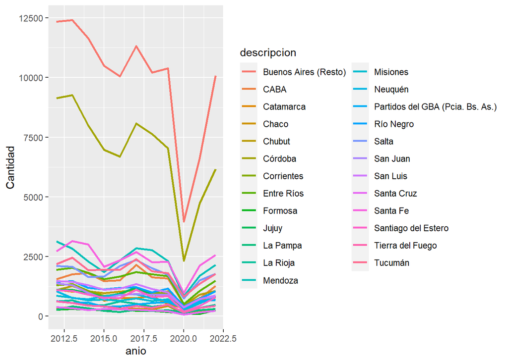

```r
cantidad_respuestas
```

- **% de los destinos:**

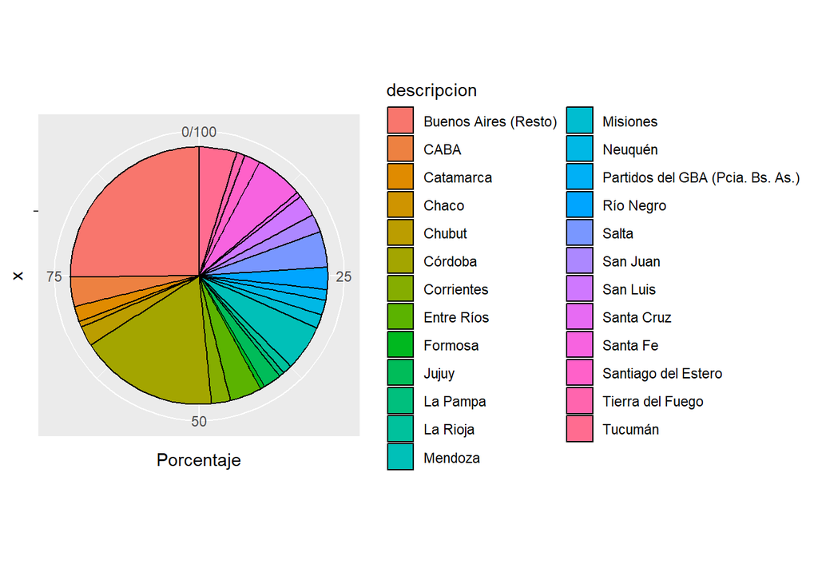

| descripcion | Porcentaje |
| --- | --- |
| Buenos Aires (Resto) | 25.2043440 |
| Córdoba | 17.4822795 |
| Santa Fe | 6.0153264 |
| Mendoza | 5.7657898 |
| Tucumán | 4.7092266 |
| Salta | 4.5337461 |
| Entre Ríos | 3.9930452 |
| CABA | 3.6692226 |
| Río Negro | 2.7527219 |
| San Luis | 2.7373127 |
| Chubut | 2.4953657 |
| Corrientes | 2.3776121 |
| San Juan | 2.2771075 |
| Jujuy | 2.2623883 |
| Santiago del Estero | 2.0110118 |
| Catamarca | 1.9525950 |
| Neuquén | 1.8900383 |
| Misiones | 1.6996086 |
| Partidos del GBA (Pcia. Bs. As.) | 1.3394479 |
| La Rioja | 1.1897260 |
| Tierra del Fuego | 1.0512734 |
| Chaco | 0.7200913 |
| La Pampa | 0.6579946 |
| Santa Cruz | 0.6264863 |
| Formosa | 0.5862385 |

```r
porcentaje_destinos
```

- **Cual es el trimestre del año en donde hay mas viajes?**
  - El trimestre 1 es el que tiene mas viajes, con un total de 139567 viajes

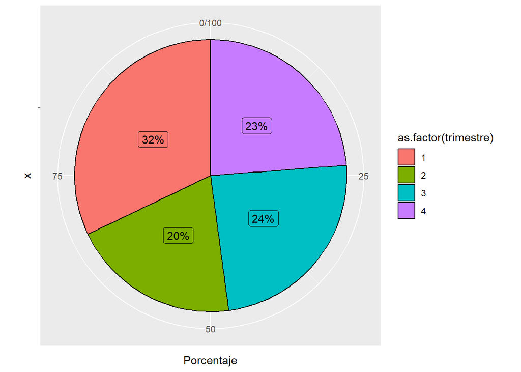

```r
porcentaje_trimestres
```